# SDGB 7844 HW 1: R Syntax and Control Structures

Name: Jiayin Hu Class Time: Thu. 1:15-3:15PM

2019-07-31

## Question 1

The vectors `state.name`, `state.area`, and `state.region` are pre-loaded in R and contain US state names, area (in square miles), and region respectively.

First, have a look at the content of these 3 vectors.

```r
state.name
```

```
##  [1] "Alabama"        "Alaska"         "Arizona"        "Arkansas"
##  [5] "California"     "Colorado"       "Connecticut"    "Delaware"
##  [9] "Florida"        "Georgia"        "Hawaii"         "Idaho"
## [13] "Illinois"       "Indiana"        "Iowa"           "Kansas"
## [17] "Kentucky"       "Louisiana"      "Maine"          "Maryland"
## [21] "Massachusetts"  "Michigan"       "Minnesota"      "Mississippi"
## [25] "Missouri"       "Montana"        "Nebraska"       "Nevada"
## [29] "New Hampshire"  "New Jersey"     "New Mexico"     "New York"
## [33] "North Carolina" "North Dakota"   "Ohio"           "Oklahoma"
## [37] "Oregon"         "Pennsylvania"   "Rhode Island"   "South Carolina"
## [41] "South Dakota"   "Tennessee"      "Texas"          "Utah"
## [45] "Vermont"        "Virginia"       "Washington"     "West Virginia"
## [49] "Wisconsin"      "Wyoming"
```

```r
state.area
```

```
##  [1]  51609 589757 113909  53104 158693 104247   5009   2057  58560  58876
## [11]   6450  83557  56400  36291  56290  82264  40395  48523  33215  10577
## [21]   8257  58216  84068  47716  69686 147138  77227 110540   9304   7836
## [31] 121666  49576  52586  70665  41222  69919  96981  45333   1214  31055
## [41]  77047  42244 267339  84916   9609  40815  68192  24181  56154  97914
```

```r
state.region
```

```
##  [1] South         West          West          South         West
##  [6] West          Northeast     South         South         South
## [11] West          West          North Central North Central North Central
## [16] North Central South         South         Northeast     South
## [21] Northeast     North Central North Central South         North Central
## [26] West          North Central West          Northeast     Northeast
## [31] West          Northeast     South         North Central North Central
## [36] South         West          Northeast     Northeast     South
## [41] North Central South         South         West          Northeast
## [46] South         West          South         North Central West
## Levels: Northeast South North Central West
```

1. Identify the data type for `state.name`, `state.area`, and `state.region`.

```r
typeof(state.name)
```

```
## [1] "character"
```

```r
typeof(state.area)
```

```
## [1] "double"
```

```r
typeof(state.region)
```

```
## [1] "integer"
```

The data type of these three vectors are character, double and integer respectively.

2. What is the longest state name (including spaces)? How long is it?

```r
#Using if statement
state.name.len = 0 # store the longest length
y <- c() #store the order number of the state with longest name

for (i in 1:length(state.name)){
  x <-  nchar(state.name[i])   #the length of each state
  if (state.name.len < x){
    state.name.len = x
    y <- i
  }
  else{
    if (state.name.len == x) y <- c(y, i)
  }
}

print(state.name[y])  #output the state name
```

```
## [1] "North Carolina" "South Carolina"
```

```r
state.name.len
```

```
## [1] 14
```

The state “North Carolina” and “South Carolina” have the longest length. They both contains 14 bytes.

3. Compute the average area of the states which contain the word “New” at the start of the state name. Use the function `substr()`.

```r
state.area.total <- 0 #initial sum of area
new.state <- c()      #store the state beginning with "New"

for (i in 1:length(state.name)){
  if(substr(state.name[i], start = 1, stop = 3) == "New"){
    new.state <- c(new.state, state.name[i])
    state.area.total <- state.area.total + state.area[i]
  }
}

print(new.state)
```

```
## [1] "New Hampshire" "New Jersey"    "New Mexico"    "New York"
```

```r
state.area.average <- state.area.total/length(new.state)
print(paste("The average area of the states which contain the word “New” at the start of the state name is", state.area.average))
```

```
## [1] "The average area of the states which contain the word “New” at the start of the state name is 47095.5"
```

4. Use the function `table()` to determine how many states are in each region. Use the function `kable()` to include the table in your solutions. (Notes: you will need the R package *knitr* to be able to use `kable()`. See the RMarkdown example in the Assignments folder on Blackboard for an example.)

```r
library(knitr)
state.table <- table(state.region)
kable(state.table, caption = "State Region Table", align = "c" )
```

State Region Table

| state.region | Freq |
| --- | --- |
| Northeast | 9 |
| South | 16 |
| North Central | 12 |
| West | 13 |

##Quesetion 2

Perfect numbers are those where the sum of the proper divisors (i.e., divisors other than the number itself) add up to the number. For example, 6 is a perfect number because its divisors, 1, 2, and 3, when summed, equal 6.

1. The following code was written to find the first 2 perfect numbers: 6 and 28; however, there are some errors in the code and the programmer forgot to add comments for readability. Debug and add comments to the following:

```r
num.perfect <- 2  #to find 2 perfect numbers
count <- 0  #the number of the perfect number we've found
iter <- 2  #the number used to check whether it is a perfect number or not. The initial value is 2.

while(count < num.perfect){  # modify <= to <. When there's less than 2 numbers, keep going

  divisor <- 1  #1 is a divisorof all numbers.

#Use for circulation to find all the divisors except the number itself.
  for(i in 2:(iter-1)){

    if(iter%%i==0) divisor <- c(divisor, i)

  } # end for loop

#Determine whether the sum of the dicisors equals to the number.
#If true, then output the number is a perfect number and add 1 to count.
  if(sum(divisor)==iter){     # modify = to ==

    print(paste(iter, " is a perfect number", sep=""))
    count <- count + 1

  } # end if

  iter <- iter + 1 #check the next number in the next circulation

} # end while loop
```

```
## [1] "6 is a perfect number"
## [1] "28 is a perfect number"
```

2. Use the function `date()` at the start and at the end of your amended code. Then compute how long the program approximately takes to run (you can do this sub- traction by hand). Find the run time when you set `num.perfect` to 1, 2, 3, and 4. Create a table of your results (Note: use the first table format in the RMarkdown Example file in the Assignments folder on Blackboard) . What are the first four perfect numbers?

```r
for (t in 1:4){
  print(date())
  num.perfect <- t  #to find t perfect numbers
  count <- 0  #the number of the perfect number we've found
  iter <- 2  #the number used to check whether it is a perfect number or not. The initial value is 2.

  while(count < num.perfect){  #When there's less than t numbers, keep going

    divisor <- 1  #1 is a divisorof all numbers.

  #Use for circulation to find all the divisors except the number itself.
    for(i in 2:(iter-1)){

      if(iter%%i==0) divisor <- c(divisor, i)

    } # end for loop

  #Determine whether the sum of the dicisors equals to the number.
  #If true, then output the number is a perfect number and add 1 to count.
    if(sum(divisor)==iter){

      print(paste(iter, " is a perfect number", sep=""))
      count <- count + 1

    } # end if

    iter <- iter + 1 #check the next number in the next circulation

  } # end while loop
  print(date())
}
```

```
## [1] "Wed Jul 31 00:13:52 2019"
## [1] "6 is a perfect number"
## [1] "Wed Jul 31 00:13:52 2019"
## [1] "Wed Jul 31 00:13:52 2019"
## [1] "6 is a perfect number"
## [1] "28 is a perfect number"
## [1] "Wed Jul 31 00:13:52 2019"
## [1] "Wed Jul 31 00:13:52 2019"
## [1] "6 is a perfect number"
## [1] "28 is a perfect number"
## [1] "496 is a perfect number"
## [1] "Wed Jul 31 00:13:52 2019"
## [1] "Wed Jul 31 00:13:52 2019"
## [1] "6 is a perfect number"
## [1] "28 is a perfect number"
## [1] "496 is a perfect number"
## [1] "8128 is a perfect number"
## [1] "Wed Jul 31 00:13:56 2019"
```

So the first 4 perfect number is 6, 28, 496, 8128. The rough run time is shown as follow.

Run Time Table

[output not shown]

3. Let x <- 1:4 and define y to be the vector of run times. Plot y vs x using the code below. Is the relationship between the discovery of perfect numbers and run times on your computer linear? Justify your answer.

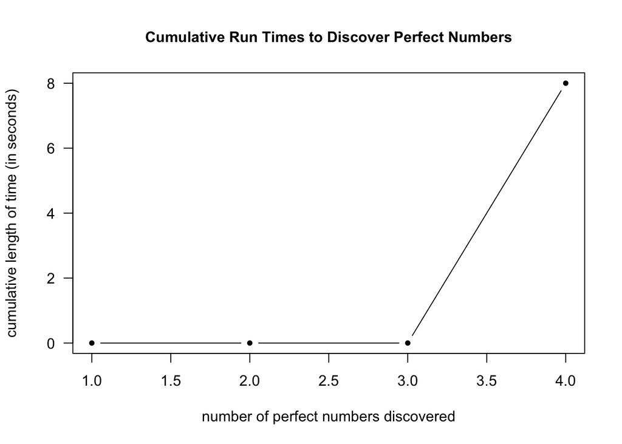

```r
x <- 1:4
y <- c(0, 0, 0, 8)
plot(x, y, pch=20, type="b", xlab="number of perfect numbers discovered",
     ylab="cumulative length of time (in seconds)",
     main="Cumulative Run Times to Discover Perfect Numbers", las=TRUE, cex.main = 1.0)
```

The relationship between the discovery of perfect numbers and run times on your computer is not linear. Run time increases significantly when the number we aim to find is larger than 3, because we have to run more than 8000 loops.

Here the time is roughly calculated by hands. In another way, we use `Sys.time()` to record the time and repeat (b) and (c). Meanwhile, this function can subtract directly to get the run time.

```r
y <- c()
for (t in 1:4){
  start <- Sys.time()
  num.perfect <- t  #to find n perfect number
  count <- 0  #the number of the perfect number we've found
  iter <- 2  #the number used to check whether it is a perfect number or not. The initial value is 2.

  while(count < num.perfect){  #When there's less than n numbers, keep going

    divisor <- 1  #1 is a divisorof all numbers.

  #Use for circulation to find all the divisors except the number itself.
    for(i in 2:(iter-1)){

      if(iter%%i==0) divisor <- c(divisor, i)

    } # end for loop

  #Determine whether the sum of the dicisors equals to the number.
  #If true, then output the number is a perfect number and add 1 to count.
    if(sum(divisor)==iter){     # ==

      print(paste(iter, " is a perfect number", sep=""))
      count <- count + 1

    } # end if

    iter <- iter + 1 #check the next number in the next circulation

  } # end while loop
  end <- Sys.time()
  time <- end - start
  y <- c(y, time)
  print(time)
}
```

```
## [1] "6 is a perfect number"
## Time difference of 5.197525e-05 secs
## [1] "6 is a perfect number"
## [1] "28 is a perfect number"
## Time difference of 0.0001180172 secs
## [1] "6 is a perfect number"
## [1] "28 is a perfect number"
## [1] "496 is a perfect number"
## Time difference of 0.0216229 secs
## [1] "6 is a perfect number"
## [1] "28 is a perfect number"
## [1] "496 is a perfect number"
## [1] "8128 is a perfect number"
## Time difference of 4.271038 secs
```

```r
x <- 1:4
timeData <- data.frame("No of Perfect Numbers"= x, "Run Time"=y)
kable(timeData, caption = "Run Time Table", align = "c" )
```

Run Time Table

| No.of.Perfect.Numbers | Run.Time |
| --- | --- |
| 1 | 0.0000520 |
| 2 | 0.0001180 |
| 3 | 0.0216229 |
| 4 | 4.2710381 |

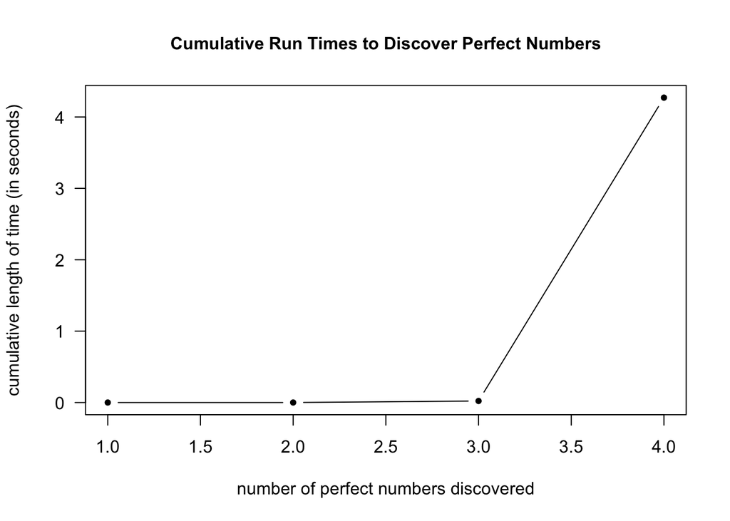

```r
plot(x, y, pch=20, type="b", xlab="number of perfect numbers discovered",
     ylab="cumulative length of time (in seconds)",
     main="Cumulative Run Times to Discover Perfect Numbers", las=TRUE, cex.main = 1.0)
```

##Question 3

1. Using a for loop, write code to compute the geometric mean of the numeric vector x < −c(4, 67, 3). Make sure your code (i) removes any NA values and (ii) prints an error message if there are any non-positive values in x.

```r
geoMean <- function(x){

  #remove any NA values
  xWithoutNa <- x[!is.na(x)]
  n <- length(xWithoutNa)
  product <- 1

  # print an error message if there are any non-positive values in x.
  if (any(xWithoutNa<=0)) cat("Error: (", x, ") contains non-positive value \n")

  else {
    for (i in 1:n){
      product <- product * xWithoutNa[i]
      geometricMean <- product^(1/n)
    }
  cat("The geometric mean of (", x, ") is", geometricMean, "\n")
  }
}

x <- c(4, 67, 3)
geoMean(x)
```

```
## The geometric mean of ( 4 67 3 ) is 9.298624
```

2. Test your code on the following cases and show the output: (i) {NA,4,67,3}, (ii) {0, NA, 6}, (iii) {67, 3, ∞}, and (iv) {−∞, 67, 3}.

```r
x1 <- c(NA,4,67,3)
x2 <- c(0, NA, 6)
x3 <- c(67, 3, Inf)
x4 <- c(-Inf, 67, 3)
for (i in 1:4){
  geoMean(eval(parse(text = paste0("x", i))))

}
```

```
## The geometric mean of ( NA 4 67 3 ) is 9.298624
## Error: ( 0 NA 6 ) contains non-positive value
## The geometric mean of ( 67 3 Inf ) is Inf
## Error: ( -Inf 67 3 ) contains non-positive value
```